# Analyse Bivariée : Prix vs Marché des Produits de Thé (Catégorie Tea)

KOUASSI KONAN LEGER

2025-06-10

# Contexte et Objectifs de l’Étude

## Problématique

La production de thé en France fait face à un défi majeur : le coût élevé de la main d’œuvre. Cette contrainte structurelle se répercute directement sur le prix final du produit, le rendant moins compétitif par rapport aux thés produits dans des pays où les coûts de production sont plus bas (Nell MARECHAL)

## Objectif de l’Étude

Cette analyse vise à comprendre comment les producteurs français de thé peuvent justifier leurs prix plus élevés sur le marché. Pour cela, nous étudions : - Les stratégies de différenciation des produits - Le positionnement sur le marché - Les arguments marketing utilisés - La relation entre la qualité perçue et les prix pratiqués

Cette étude permettra d’identifier les leviers sur lesquels les producteurs français peuvent s’appuyer pour maintenir leur compétitivité malgré des coûts de production plus élevés.

# Analyse du Tea brut

## 1. Chargement des Données et Packages

```r
# Chargement des packages nécessaires
library(readxl)
library(tidyverse)
library(dplyr)
library(lubridate)
library(wordcloud)
library(tidytext)
library(scales)
library(car) # Pour les tests statistiques
library(rstatix) # Pour les tests statistiques
library(ggpubr) # Pour les visualisations statistiques

# Nettoyage de l'environnement
rm(list = ls())

# Importation des données
gnpd <- read_excel("GNPD_tea.xlsx")

# Préparation des données
gnpd <- gnpd %>%
  mutate(
    `Price per 100 g/ml in Euros` = as.numeric(`Price per 100 g/ml in Euros`),
    `Price in US Dollars` = as.numeric(`Price in US Dollars`),
    `Price in Euros` = as.numeric(`Price in Euros`),
    `Unit Pack Size (ml/g)` = as.numeric(`Unit Pack Size (ml/g)`),
    `Alcohol By Volume (%)` = as.numeric(`Alcohol By Volume (%)`),
    `Bar Code` = as.character(`Bar Code`),
    `Date Published` = as.Date(`Date Published`)
  )

# Filtrage pour ne garder que la catégorie Tea
gnpd_tea <- gnpd %>%
  filter(`Sub-Category` == "Tea",Market=="France") %>%
  filter(!is.na(`Price per 100 g/ml in Euros`))

# Filtrage des valeurs aberrantes
gnpd_french_market_tea <- gnpd_tea %>%
  filter(`Unit Pack Size (ml/g)` >= 2.00,
         `Unit Pack Size (ml/g)` <= 5000.00,
         `Price per 100 g/ml in Euros` != 0.00)

# Calcul de la proportion conservée
total_lignes <- nrow(gnpd_tea)
proportion_conservee <- nrow(gnpd_french_market_tea) / total_lignes
cat("Proportion des données conservées :", round(proportion_conservee * 100, 2), "%\n")
```

```
## Proportion des données conservées : 85.86 %
```

## 2. Analyse du thé du marché français

### 2.1 Résumé Statistique des Variables

```r
# Résumé statistique du prix
summary_prix <- summary(gnpd_french_market_tea$`Price per 100 g/ml in Euros`)
print("Résumé statistique du prix :")
```

```
## [1] "Résumé statistique du prix :"
```

```r
print(summary_prix)
```

```
##    Min. 1st Qu.  Median    Mean 3rd Qu.    Max.
##    0.05    4.99    7.71   10.68   12.90   90.00
```

```r
# Test de normalité de Shapiro-Wilk
shapiro_test <- shapiro.test(gnpd_french_market_tea$`Price per 100 g/ml in Euros`)
print("Test de normalité de Shapiro-Wilk :")
```

```
## [1] "Test de normalité de Shapiro-Wilk :"
```

```r
print(shapiro_test)
```

```
##
##  Shapiro-Wilk normality test
##
## data:  gnpd_french_market_tea$`Price per 100 g/ml in Euros`
## W = 0.7644, p-value < 2.2e-16
```

### 2.2 Analyse des Bornes de Tukey

```r
# Calcul des bornes de Tukey
prix <- gnpd_french_market_tea$`Price per 100 g/ml in Euros`
prix <- na.omit(prix)
Q1 <- quantile(prix, 0.25)
Q3 <- quantile(prix, 0.75)
IQR <- Q3 - Q1
borne_inf <- Q1 - 1.5 * IQR
borne_sup <- Q3 + 1.5 * IQR

# Affichage des bornes pour info
cat("Limites de Tukey : [", round(borne_inf, 2), ";", round(borne_sup, 2), "]\n")
```

```
## Limites de Tukey : [ -6.88 ; 24.76 ]
```

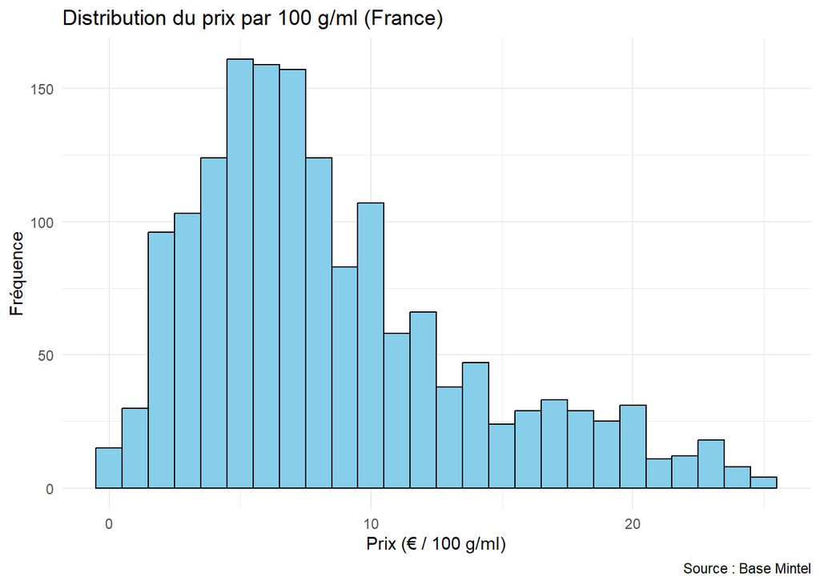

```r
library(ggplot2)

ggplot(gnpd_french_market_tea %>%
         filter(!is.na(`Price per 100 g/ml in Euros`),
                `Price per 100 g/ml in Euros`<=borne_sup),
       aes(x = `Price per 100 g/ml in Euros`)) +
  geom_histogram(binwidth = 1, fill = "skyblue", color = "black") +
  labs(title = "Distribution du prix par 100 g/ml (France)",
       x = "Prix (€ / 100 g/ml)", y = "Fréquence",
       caption = "Source : Base Mintel") +
  theme_minimal()
```

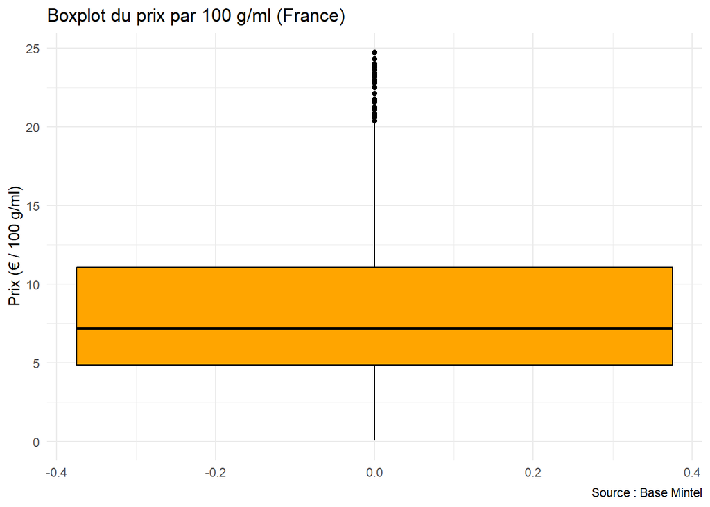

```r
ggplot(gnpd_french_market_tea%>%
         filter(!is.na(`Price per 100 g/ml in Euros`),
                `Price per 100 g/ml in Euros`<=borne_sup), aes(y = `Price per 100 g/ml in Euros`)) +
  geom_boxplot(fill = "orange", color = "black") +
  labs(title = "Boxplot du prix par 100 g/ml (France)",
       y = "Prix (€ / 100 g/ml)",
       caption = "Source : Base Mintel") +
  theme_minimal()
```

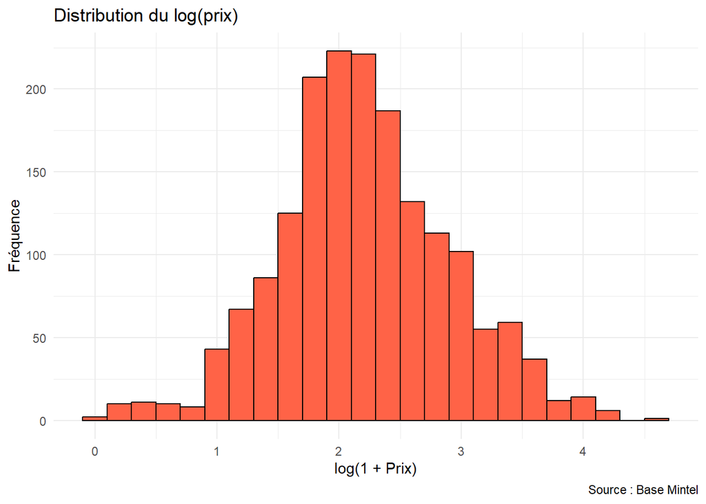

```r
ggplot(gnpd_french_market_tea, aes(x = log1p(`Price per 100 g/ml in Euros`))) +
  geom_histogram(binwidth = 0.2, fill = "tomato", color = "black") +
  labs(title = "Distribution du log(prix)", x = "log(1 + Prix)", y = "Fréquence",
       caption = "Source : Base Mintel") +
  theme_minimal()
```

### Evolution du prix du thé français au cours temps

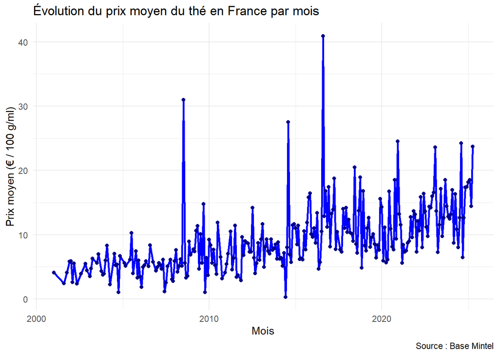

```r
library(lubridate)
library(dplyr)

# Créer une colonne "mois"
gnpd_french_market_tea <- gnpd_french_market_tea %>%
  mutate(Mois = floor_date(as.Date(`Date Published`), unit = "month"))

# Creation de la variable mois
prix_par_mois <- gnpd_french_market_tea %>%
  filter(!is.na(`Price per 100 g/ml in Euros`)) %>%
  group_by(Mois) %>%
  summarise(Prix_moyen = mean(`Price per 100 g/ml in Euros`))

# Calcul du prix moyen par mois
prix_par_mois <- gnpd_french_market_tea %>%
  filter(!is.na(`Price per 100 g/ml in Euros`)) %>%
  group_by(Mois) %>%
  summarise(Prix_moyen = mean(`Price per 100 g/ml in Euros`))

# Representation graphique
library(ggplot2)

ggplot(prix_par_mois, aes(x = Mois, y = Prix_moyen)) +
  geom_line(color = "blue", size = 1) +
  geom_point(color = "darkblue", size = 1.5) +
  labs(title = "Évolution du prix moyen du thé en France par mois",
       x = "Mois",
       y = "Prix moyen (€ / 100 g/ml)",
       caption = "Source : Base Mintel") +
  theme_minimal()
```

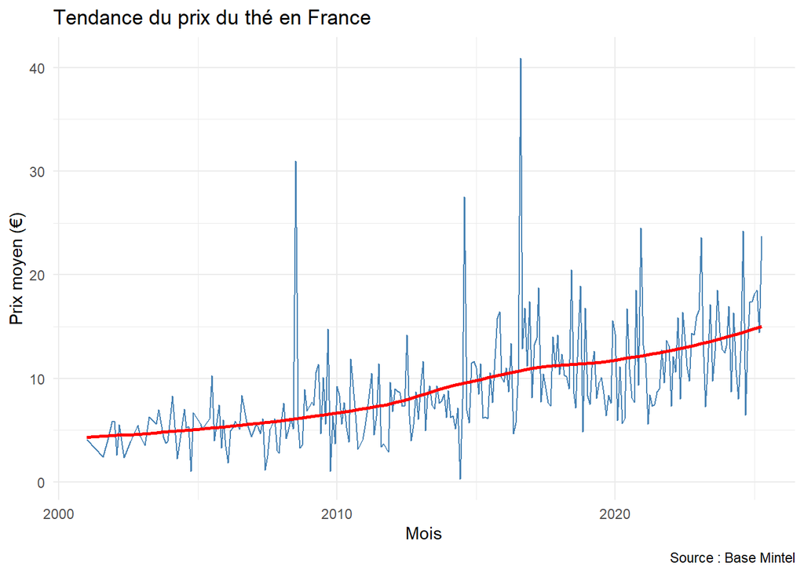

```r
# AUtre option
ggplot(prix_par_mois, aes(x = Mois, y = Prix_moyen)) +
  geom_line(color = "steelblue") +
  geom_smooth(method = "loess", color = "red", se = FALSE) +
  labs(title = "Tendance du prix du thé en France",
       x = "Mois", y = "Prix moyen (€)",
       caption = "Source : Base Mintel") +
  theme_minimal()
```

### par année

```r
# Calcul des prix moyens par année
```

```r
prix_par_annee <- gnpd_french_market_tea %>%
  mutate(annee = lubridate::year(`Date Published`)) %>%
  filter(!is.na(`Price per 100 g/ml in Euros`),
         !is.na(annee)) %>%
  group_by(annee) %>%
  summarise(
    n = n(),
    prix_moyen = mean(`Price per 100 g/ml in Euros`, na.rm = TRUE),
    prix_median = median(`Price per 100 g/ml in Euros`, na.rm = TRUE),
    prix_min = min(`Price per 100 g/ml in Euros`, na.rm = TRUE),
    prix_max = max(`Price per 100 g/ml in Euros`, na.rm = TRUE)
  ) %>%
  arrange(annee)
```

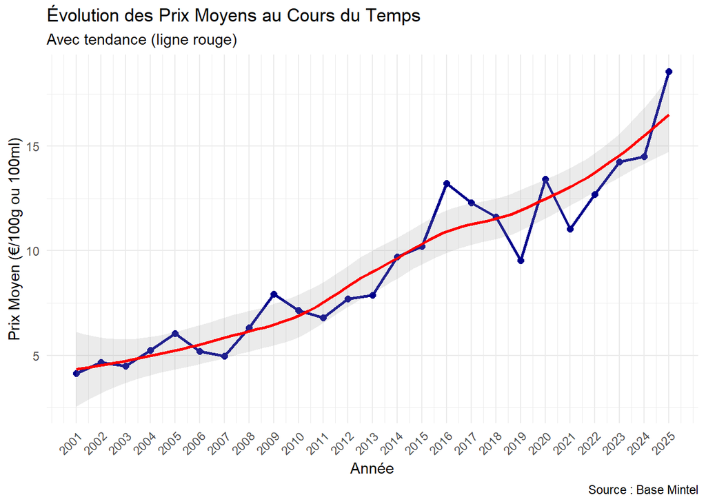

```r
# Graphique de l'évolution des prix moyens
ggplot(prix_par_annee, aes(x = annee, y = prix_moyen)) +
  geom_line(color = "darkblue", size = 1) +
  geom_point(color = "darkblue", size = 2) +
  geom_smooth(method = "loess", se = TRUE, color = "red", alpha = 0.2) +
  labs(
    title = "Évolution des Prix Moyens au Cours du Temps",
    subtitle = "Avec tendance (ligne rouge)",
    x = "Année",
    y = "Prix Moyen (€/100g ou 100ml)",
    caption = "Source : Base Mintel"
  ) +
  theme_minimal() +
  scale_x_continuous(breaks = seq(min(prix_par_annee$annee), max(prix_par_annee$annee), by = 1)) +
  theme(axis.text.x = element_text(angle = 45, hjust = 1))
```

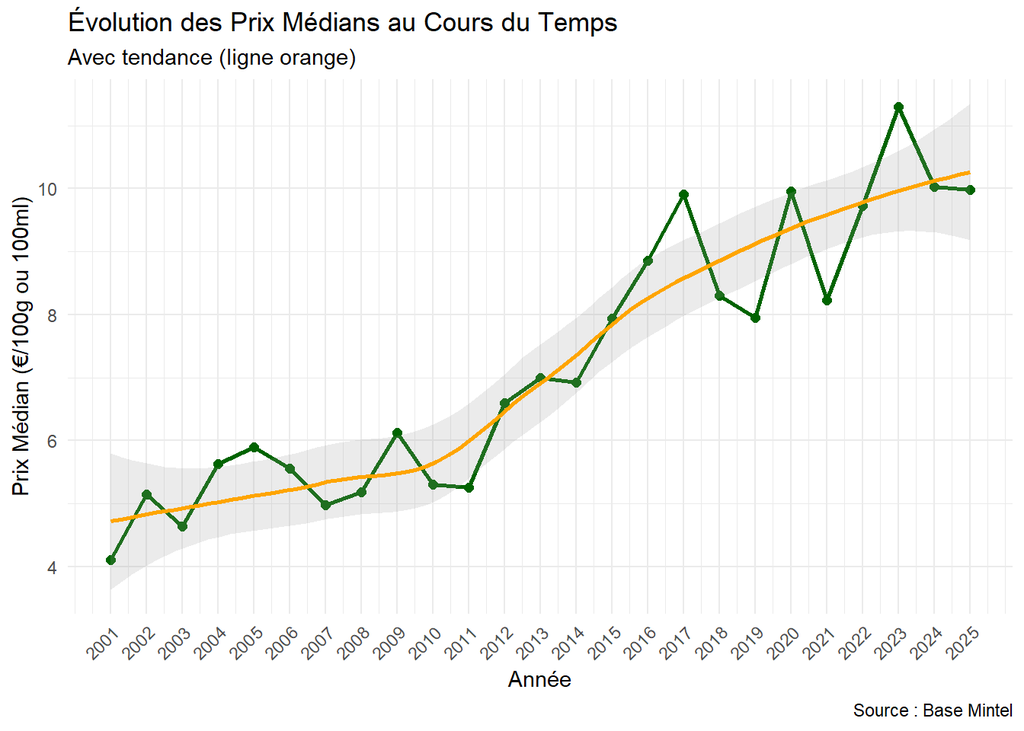

```r
##### prix median

ggplot(prix_par_annee, aes(x = annee, y = prix_median)) +
  geom_line(color = "darkgreen", size = 1) +
  geom_point(color = "darkgreen", size = 2) +
  geom_smooth(method = "loess", se = TRUE, color = "orange", alpha = 0.2) +
  labs(
    title = "Évolution des Prix Médians au Cours du Temps",
    subtitle = "Avec tendance (ligne orange)",
    x = "Année",
    y = "Prix Médian (€/100g ou 100ml)",
    caption = "Source : Base Mintel"
  ) +
  theme_minimal() +
  scale_x_continuous(breaks = seq(min(prix_par_annee$annee), max(prix_par_annee$annee), by = 1)) +
  theme(axis.text.x = element_text(angle = 45, hjust = 1))
```

```r
# Affichage des statistiques annuelles
knitr::kable(prix_par_annee,
             caption = "Statistiques des Prix par Année")
```

Statistiques des Prix par Année

| annee | n | prix_moyen | prix_median | prix_min | prix_max |
| --- | --- | --- | --- | --- | --- |
| 2001 | 4 | 4.130000 | 4.110 | 2.46 | 5.84 |
| 2002 | 11 | 4.651818 | 5.150 | 2.37 | 7.14 |
| 2003 | 16 | 4.496250 | 4.635 | 2.30 | 6.97 |
| 2004 | 9 | 5.248889 | 5.630 | 1.04 | 8.31 |
| 2005 | 23 | 6.032609 | 5.900 | 2.06 | 10.73 |
| 2006 | 27 | 5.181852 | 5.560 | 0.05 | 13.90 |
| 2007 | 30 | 4.953333 | 4.975 | 0.34 | 8.33 |
| 2008 | 41 | 6.314878 | 5.180 | 0.32 | 31.00 |
| 2009 | 23 | 7.932174 | 6.130 | 1.07 | 27.50 |
| 2010 | 28 | 7.136786 | 5.305 | 1.90 | 18.33 |
| 2011 | 28 | 6.787500 | 5.255 | 1.06 | 25.68 |
| 2012 | 81 | 7.709383 | 6.600 | 0.07 | 28.25 |
| 2013 | 131 | 7.886794 | 7.000 | 0.78 | 34.15 |
| 2014 | 148 | 9.714595 | 6.925 | 0.30 | 50.00 |
| 2015 | 144 | 10.200347 | 7.935 | 0.30 | 33.32 |
| 2016 | 128 | 13.218828 | 8.850 | 1.78 | 90.00 |
| 2017 | 128 | 12.286953 | 9.910 | 0.28 | 52.00 |
| 2018 | 98 | 11.623980 | 8.300 | 0.90 | 49.83 |
| 2019 | 115 | 9.522261 | 7.950 | 0.53 | 42.50 |
| 2020 | 85 | 13.430235 | 9.950 | 1.56 | 62.50 |
| 2021 | 93 | 11.030538 | 8.230 | 0.27 | 43.18 |
| 2022 | 120 | 12.700250 | 9.725 | 0.37 | 46.67 |
| 2023 | 70 | 14.255714 | 11.295 | 0.30 | 47.50 |
| 2024 | 121 | 14.517190 | 10.030 | 0.76 | 67.50 |
| 2025 | 29 | 18.568621 | 9.980 | 1.46 | 51.25 |

## correcteion des prix par l’inflation

```r
inflation_rates <- data.frame(
  Annee = 1998:2025,
  Inflation_pct = c(0.6, 0.5, 1.7, 1.6, 1.9, 2.1, 2.1, 1.7, 1.7,1.5,2.8,0.1,1.5,2.1,2.0,0.9,0.5,0.0,0.2,1.0,1.9,1.1,0.5,1.6,5.2,4.9,2.0,NA)
)

# construction de l'IPC
inflation_rates$IPC <- NA
inflation_rates$IPC[1] <- 100

for (i in 2:nrow(inflation_rates)) {
  inflation_rates$IPC[i] <- inflation_rates$IPC[i - 1] * (1 + inflation_rates$Inflation_pct[i] / 100)
}


gnpd_french_market_tea$Annee <- year(as.Date(gnpd_french_market_tea$`Date Published`))
# joindre le taux d'inflation et l'IPC à la base
gnpd_french_market_tea <- gnpd_french_market_tea %>%
  left_join(inflation_rates[, c("Annee", "IPC")], by = "Annee")

# choix de l'année de reference
ipc_ref <- inflation_rates$IPC[inflation_rates$Annee == 2024]

# Correction du prix
gnpd_french_market_tea <- gnpd_french_market_tea %>%
  mutate(Prix_corrige = `Price per 100 g/ml in Euros` * (ipc_ref / IPC))
```

# reprise des cacluls avec le prix corrigé

```r
prix_par_annee <- gnpd_french_market_tea %>%
  mutate(annee = lubridate::year(`Date Published`)) %>%
  filter(!is.na(Prix_corrige),
         !is.na(annee)) %>%
  group_by(annee) %>%
  summarise(
    n = n(),
    prix_moyen = mean(Prix_corrige, na.rm = TRUE),
    prix_median = median(Prix_corrige, na.rm = TRUE),
    prix_min = min(Prix_corrige, na.rm = TRUE),
    prix_max = max(Prix_corrige, na.rm = TRUE)
  ) %>%
  arrange(annee)
```

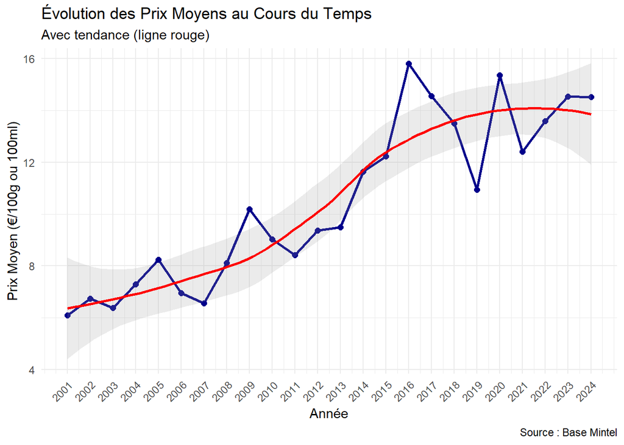

```r
# Graphique de l'évolution des prix moyens
ggplot(prix_par_annee, aes(x = annee, y = prix_moyen)) +
  geom_line(color = "darkblue", size = 1) +
  geom_point(color = "darkblue", size = 2) +
  geom_smooth(method = "loess", se = TRUE, color = "red", alpha = 0.2) +
  labs(
    title = "Évolution des Prix Moyens au Cours du Temps",
    subtitle = "Avec tendance (ligne rouge)",
    x = "Année",
    y = "Prix Moyen (€/100g ou 100ml)",
    caption = "Source : Base Mintel"
  ) +
  theme_minimal() +
  scale_x_continuous(breaks = seq(min(prix_par_annee$annee), max(prix_par_annee$annee), by = 1)) +
  theme(axis.text.x = element_text(angle = 45, hjust = 1))
```

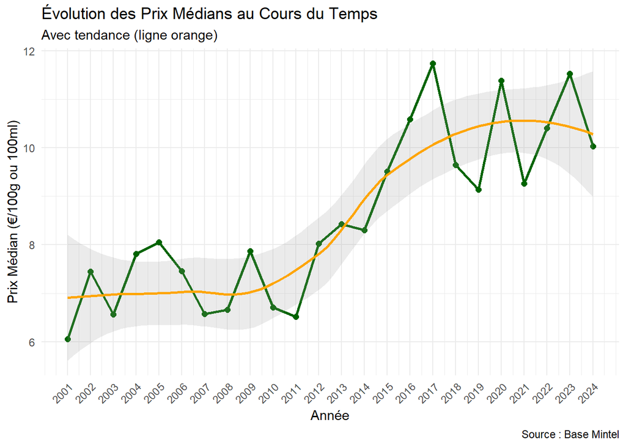

```r
##### prix median

ggplot(prix_par_annee, aes(x = annee, y = prix_median)) +
  geom_line(color = "darkgreen", size = 1) +
  geom_point(color = "darkgreen", size = 2) +
  geom_smooth(method = "loess", se = TRUE, color = "orange", alpha = 0.2) +
  labs(
    title = "Évolution des Prix Médians au Cours du Temps",
    subtitle = "Avec tendance (ligne orange)",
    x = "Année",
    y = "Prix Médian (€/100g ou 100ml)",
    caption = "Source : Base Mintel"
  ) +
  theme_minimal() +
  scale_x_continuous(breaks = seq(min(prix_par_annee$annee), max(prix_par_annee$annee), by = 1)) +
  theme(axis.text.x = element_text(angle = 45, hjust = 1))
```

## Comparaison du prix corrigé et non corrigé

```r
prix_comparatif <- gnpd_french_market_tea %>%
  mutate(annee = lubridate::year(`Date Published`)) %>%
  filter(!is.na(`Price per 100 g/ml in Euros`), !is.na(Prix_corrige)) %>%
  group_by(annee) %>%
  summarise(
    prix_moyen_non_corrige = mean(`Price per 100 g/ml in Euros`, na.rm = TRUE),
    prix_moyen_corrige = mean(Prix_corrige, na.rm = TRUE)
  ) %>%
  pivot_longer(cols = c(prix_moyen_non_corrige, prix_moyen_corrige),
               names_to = "type_prix",
               values_to = "valeur")
```

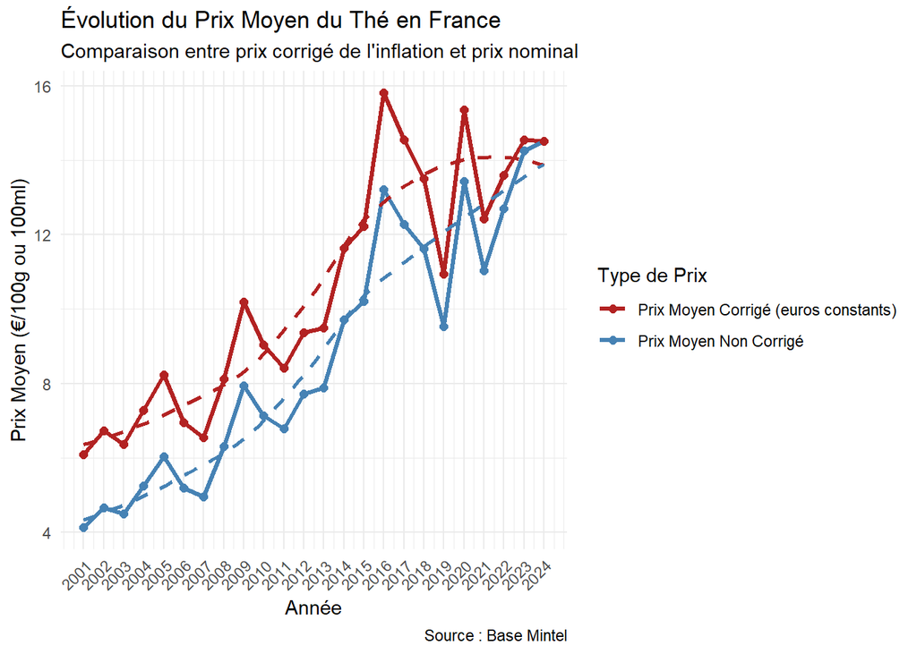

```r
library(ggplot2)

ggplot(prix_comparatif, aes(x = annee, y = valeur, color = type_prix)) +
  geom_line(size = 1.2) +
  geom_point(size = 2) +
  geom_smooth(method = "loess", se = FALSE, linetype = "dashed", size = 1) +
  scale_color_manual(
    values = c(
      "prix_moyen_non_corrige" = "steelblue",
      "prix_moyen_corrige" = "firebrick"
    ),
    labels = c(
      "prix_moyen_non_corrige" = "Prix Moyen Non Corrigé",
      "prix_moyen_corrige" = "Prix Moyen Corrigé (euros constants)"
    )
  ) +
  labs(
    title = "Évolution du Prix Moyen du Thé en France",
    subtitle = "Comparaison entre prix corrigé de l'inflation et prix nominal",
    x = "Année",
    y = "Prix Moyen (€/100g ou 100ml)",
    color = "Type de Prix",
    caption = "Source : Base Mintel"
  ) +
  theme_minimal() +
  scale_x_continuous(breaks = seq(min(prix_comparatif$annee), max(prix_comparatif$annee), by = 1)) +
  theme(axis.text.x = element_text(angle = 45, hjust = 1))
```

# Analyse des type de produit lancés sur le marché français

```r
library(dplyr)
library(ggplot2)

# Comptage des types de lancement
launch_dist <- gnpd_french_market_tea %>%
  filter(!is.na(`Launch Type`)) %>%
  count(`Launch Type`, sort = TRUE)

print(launch_dist)
```

```
## # A tibble: 5 × 2
##   `Launch Type`                   n
##   <chr>                       <int>
## 1 New Variety/Range Extension   790
## 2 New Product                   453
## 3 New Packaging                 393
## 4 Relaunch                       77
## 5 New Formulation                18
```

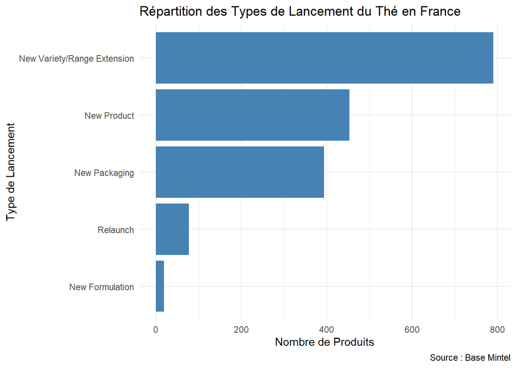

```r
ggplot(launch_dist, aes(x = reorder(`Launch Type`, n), y = n)) +
  geom_bar(stat = "identity", fill = "steelblue") +
  coord_flip() +
  labs(
    title = "Répartition des Types de Lancement du Thé en France",
    x = "Type de Lancement",
    y = "Nombre de Produits",
    caption = "Source : Base Mintel"
  ) +
  theme_minimal()
```

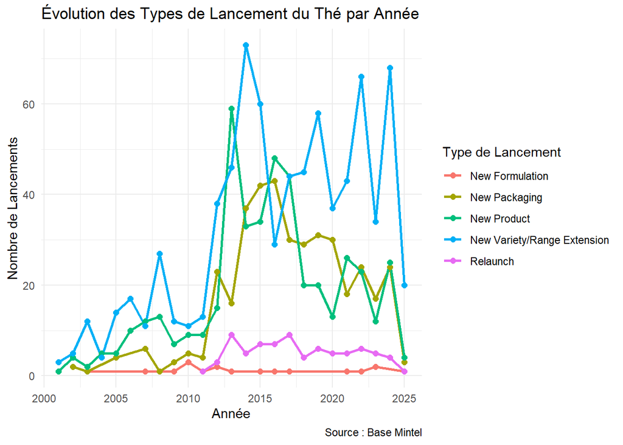

```r
launch_evolution <- gnpd_french_market_tea %>%
  mutate(annee = lubridate::year(`Date Published`)) %>%
  filter(!is.na(`Launch Type`)) %>%
  group_by(annee, `Launch Type`) %>%
  summarise(n = n()) %>%
  ungroup()

ggplot(launch_evolution, aes(x = annee, y = n, color = `Launch Type`)) +
  geom_line(size = 1) +
  geom_point(size = 2) +
  labs(
    title = "Évolution des Types de Lancement du Thé par Année",
    x = "Année",
    y = "Nombre de Lancements",
    color = "Type de Lancement",
    caption = "Source : Base Mintel"
  ) +
  theme_minimal()
```

## test statistiques

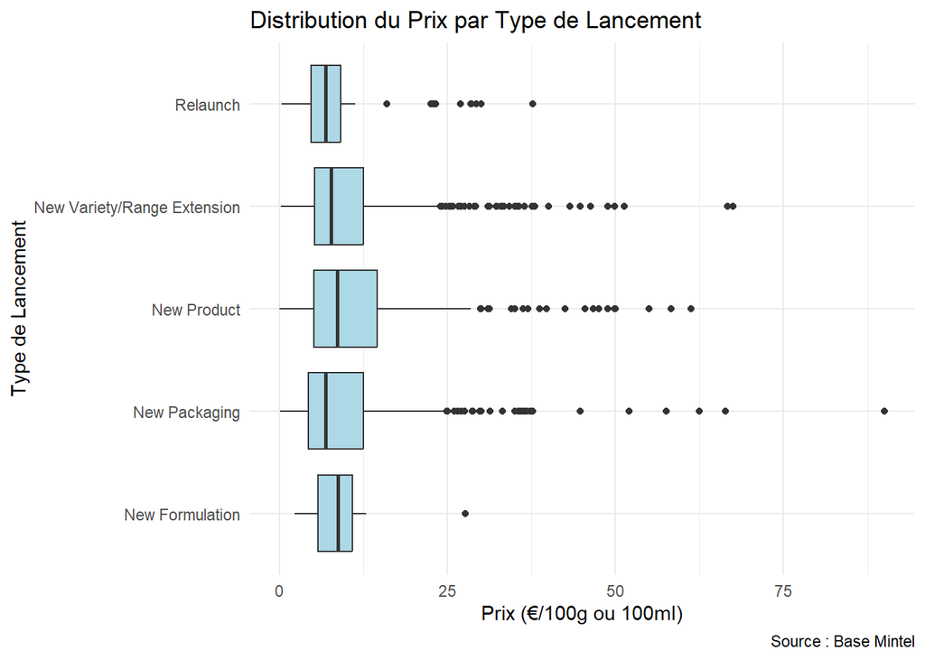

```r
library(ggplot2)

ggplot(gnpd_french_market_tea, aes(x = `Launch Type`, y = `Price per 100 g/ml in Euros`)) +
  geom_boxplot(fill = "lightblue") +
  coord_flip() +
  labs(
    title = "Distribution du Prix par Type de Lancement",
    x = "Type de Lancement",
    y = "Prix (€/100g ou 100ml)",
    caption = "Source : Base Mintel"
  ) +
  theme_minimal()
```

```r
kruskal.test(`Price per 100 g/ml in Euros` ~ `Launch Type`, data = gnpd_french_market_tea)
```

```
##
##  Kruskal-Wallis rank sum test
##
## data:  Price per 100 g/ml in Euros by Launch Type
## Kruskal-Wallis chi-squared = 14.72, df = 4, p-value = 0.005318
```

# Interpretation

Le test de Kruskal-Wallis a été réalisé pour évaluer s’il existe une différence significative entre les prix du thé (€/100g ou 100ml) selon les différents types de lancement de produit (Launch Type).

Statistique du test : χ² = 14.72 Degrés de liberté : 4 p-value : 0.0053 Puisque la p-value est inférieure au seuil usuel de 0.05, on rejette l’hypothèse nulle d’égalité des distributions des prix entre les groupes.

👉 Il existe donc à priori une différence statistiquement significative du prix moyen du thé selon le type de lancement

# Analyse de la variable private label

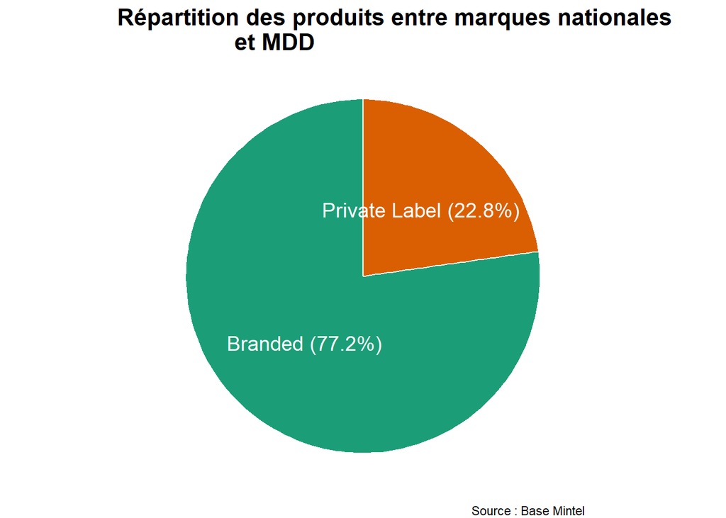

```r
library(ggplot2)
library(dplyr)

# Préparer les données
private_label_pie <- gnpd_french_market_tea %>%
  filter(!is.na(`Private Label`)) %>%
  count(`Private Label`) %>%
  mutate(
    pourcentage = round(100 * n / sum(n), 1),
    label = paste0(`Private Label`, " (", pourcentage, "%)")
  )

# Graphique en camembert
ggplot(private_label_pie, aes(x = "", y = n, fill = `Private Label`)) +
  geom_col(width = 1, color = "white") +
  coord_polar(theta = "y") +
  geom_text(aes(label = label), position = position_stack(vjust = 0.5), color = "white", size = 5) +
  scale_fill_manual(values = c("#1b9e77", "#d95f02")) +
  labs(
    title = "Répartition des produits entre marques nationales
    et MDD",
    fill = "Type de marque",
    caption = "Source : Base Mintel"
  ) +
  theme_void() +
  theme(
    plot.title = element_text(hjust = 0.2, size = 16, face = "bold"),
    legend.position = "none"
  )
```

```r
rm(private_label_pie)
```

# Resumé statistique

```r
gnpd_french_market_tea %>%
  filter(!is.na(`Private Label`), !is.na(`Price per 100 g/ml in Euros`)) %>%
  group_by(`Private Label`) %>%
  summarise(
    n = n(),
    prix_moyen = mean(`Price per 100 g/ml in Euros`, na.rm = TRUE),
    prix_median = median(`Price per 100 g/ml in Euros`, na.rm = TRUE),
    prix_min = min(`Price per 100 g/ml in Euros`, na.rm = TRUE),
    prix_max = max(`Price per 100 g/ml in Euros`, na.rm = TRUE)
  )
```

```
## # A tibble: 2 × 6
##   `Private Label`     n prix_moyen prix_median prix_min prix_max
##   <chr>           <int>      <dbl>       <dbl>    <dbl>    <dbl>
## 1 Branded          1337      11.8         8.57     0.05       90
## 2 Private Label     394       6.90        5.02     0.07       50
```

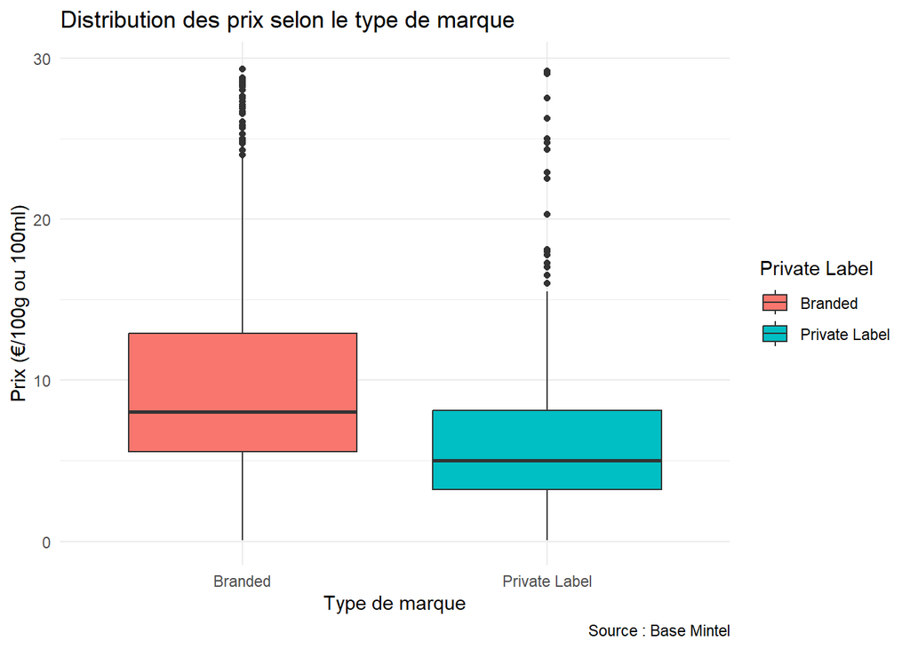

```r
ggplot(gnpd_french_market_tea, aes(x = `Private Label`, y = `Price per 100 g/ml in Euros`, fill = `Private Label`)) +
  geom_boxplot() +
  scale_y_continuous(limits = c(0, quantile(gnpd_french_market_tea$`Price per 100 g/ml in Euros`, 0.95, na.rm = TRUE))) +
  labs(
    title = "Distribution des prix selon le type de marque",
    x = "Type de marque",
    y = "Prix (€/100g ou 100ml)",
    caption = "Source : Base Mintel"
  ) +
  theme_minimal()
```

## test de wilcoxon

```r
wilcox.test(`Price per 100 g/ml in Euros` ~ `Private Label`, data = gnpd_french_market_tea)
```

```
##
##  Wilcoxon rank sum test with continuity correction
##
## data:  Price per 100 g/ml in Euros by Private Label
## W = 372737, p-value < 2.2e-16
## alternative hypothesis: true location shift is not equal to 0
```

## Interpretation

Le test est hautement significatif (p < 0.001) → On rejette l’hypothèse nulle selon laquelle les deux groupes ont la même distribution des prix (en particulier, la même médiane).

Conclusion : Il existe une différence statistiquement significative entre les prix des produits “Branded” et “Private Label”.

## Construction de modele d’un premier modele

```r
lm_model <- lm(`Price per 100 g/ml in Euros` ~ `Private Label`, data = gnpd_french_market_tea)
summary(lm_model)
```

```
##
## Call:
## lm(formula = `Price per 100 g/ml in Euros` ~ `Private Label`,
##     data = gnpd_french_market_tea)
##
## Residuals:
##     Min      1Q  Median      3Q     Max
## -11.747  -5.397  -2.737   2.203  78.203
##
## Coefficients:
##                              Estimate Std. Error t value Pr(>|t|)
## (Intercept)                   11.7974     0.2542  46.415   <2e-16 ***
## `Private Label`Private Label  -4.8944     0.5328  -9.187   <2e-16 ***
## ---
## Signif. codes:  0 '***' 0.001 '**' 0.01 '*' 0.05 '.' 0.1 ' ' 1
##
## Residual standard error: 9.294 on 1729 degrees of freedom
## Multiple R-squared:  0.04654,    Adjusted R-squared:  0.04599
## F-statistic:  84.4 on 1 and 1729 DF,  p-value: < 2.2e-16
```

## analyse de la qualité du thé sur marché français

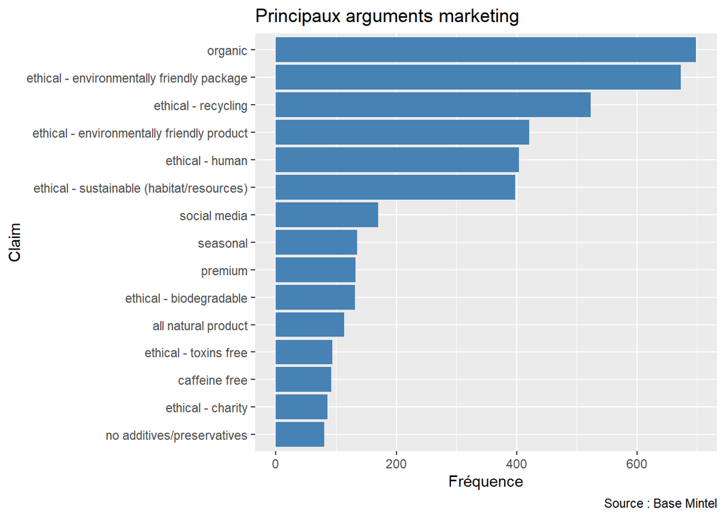

```r
# Extraction des claims individuels
claims <- gnpd_french_market_tea %>%
  filter(!is.na(`Positioning Claims`)) %>%
  unnest_tokens(claim, `Positioning Claims`, token = "regex",
                pattern = ",\\s*") %>%
  count(claim, sort = TRUE)

# Barplot des claims les plus fréquents
claims %>%
  slice_max(n, n = 15) %>%
  ggplot(aes(x = reorder(claim, n), y = n)) +
  geom_col(fill = "steelblue") +
  coord_flip() +
  labs(title = "Principaux arguments marketing", x = "Claim", y = "Fréquence",caption = "Source : Base Mintel")
```

```r
library(dplyr)
library(tidyr)

# Séparation des claims
claims_table <- gnpd_french_market_tea %>%
  separate_rows(`Positioning Claims`, sep = ",") %>%
  filter(!is.na(`Positioning Claims`)) %>%
  mutate(`Positioning Claims` = trimws(`Positioning Claims`)) %>%  # Nettoyage des espaces
  count(`Positioning Claims`, sort = TRUE)

# Top 15 + regroupement des autres
top_n <- 15

claims_table_top15 <- claims_table %>%
  mutate(`Positioning Claims` = ifelse(row_number() <= top_n, `Positioning Claims`, "Autres")) %>%
  group_by(`Positioning Claims`) %>%
  summarise(Frequence = sum(n), .groups = "drop") %>%
  arrange(desc(Frequence)) %>%
  mutate(Part = round(Frequence / sum(Frequence) * 100, 2))

# Affichage du tableau final
claims_table_top15
```

```
## # A tibble: 16 × 3
##    `Positioning Claims`                       Frequence  Part
##    <chr>                                          <int> <dbl>
##  1 Autres                                           884 17.6
##  2 Organic                                          698 13.9
##  3 Ethical - Environmentally Friendly Package       673 13.4
##  4 Ethical - Recycling                              523 10.4
##  5 Ethical - Environmentally Friendly Product       421  8.36
##  6 Ethical - Human                                  404  8.03
##  7 Ethical - Sustainable (Habitat/Resources)        398  7.91
##  8 Social Media                                     170  3.38
##  9 Seasonal                                         135  2.68
## 10 Premium                                          132  2.62
## 11 Ethical - Biodegradable                          131  2.6
## 12 All Natural Product                              113  2.24
## 13 Ethical - Toxins Free                             94  1.87
## 14 Caffeine Free                                     92  1.83
## 15 Ethical - Charity                                 86  1.71
## 16 No Additives/Preservatives                        80  1.59
```

Les claims marketing ont été regroupés en six catégories, selon les typologies proposées par Grunert (2005), Verbeke (2008), Aschemann-Witzel et al. (2013), et Kihlberg & Risvik (2007), qui distinguent les dimensions nutritionnelles, fonctionnelles, environnementales, sensorielles, pratiques, et socio-démographiques des allégations de produits alimentaires.

```r
library(dplyr)
library(stringr)

# Définir les mots-clés pour chaque catégorie
claims_sante <- c("antioxidant", "functional - digestive", "functional - energy", "functional - slimming",
                  "functional - other", "functional - stress & sleep", "functional - immune system",
                  "functional - beauty benefits", "functional - brain & nervous system",
                  "functional - cardiovascular", "functional - bone health", "functional - skin",
                  "high satiety", "anti-ageing", "nails & hair", "vitamin/mineral fortified")

claims_nutrition <- c("caffeine free", "no additives/preservatives", "free from added/artificial flavourings",
                      "free from added/artificial additives", "free from added/artificial preservatives",
                      "free from added/artificial colourings", "low/no/reduced allergen", "low/no/reduced calorie",
                      "vegetarian", "vegan/no animal ingredients", "kosher", "gmo free", "sugar free",
                      "no added sugar", "diabetic", "low/no/reduced fat", "low/no/reduced sodium",
                      "low/no/reduced lactose", "wholegrain")

claims_ethique <- c("organic", "ethical - environmentally friendly package", "ethical - recycling",
                    "ethical - environmentally friendly product", "ethical - human",
                    "ethical - sustainable (habitat/resources)", "ethical - toxins free",
                    "ethical - biodegradable", "ethical - charity", "carbon neutral", "ethical - animal")

claims_packaging <- c("convenient packaging", "time/speed", "ease of use", "interesting packaging",
                      "microwaveable", "refill/refillable", "portionability", "on-the-go")

claims_marketing <- c("premium", "social media", "seasonal", "limited edition", "event merchandising",
                      "novel", "cobranded", "economy")

claims_ciblage <- c("maternal", "children (5-12)", "female", "male", "plant based")

# Fonction pour détecter la présence d'un mot-clé
detect_claim <- function(text, keywords) {
  if (is.na(text)) return("non")
  any(str_detect(text, fixed(keywords, ignore_case = TRUE))) %>% ifelse("oui", "non")
}

# Créer les colonnes
gnpd_french_market_tea <- gnpd_french_market_tea %>%
  mutate(claim_sante = map_chr(`Positioning Claims`, ~ detect_claim(.x, claims_sante)))
gnpd_french_market_tea <- gnpd_french_market_tea %>%
  mutate(
    claim_nutrition = map_chr(`Positioning Claims`, ~ detect_claim(.x, claims_nutrition)))
gnpd_french_market_tea <- gnpd_french_market_tea %>%
  mutate(
    claim_ethique = map_chr(`Positioning Claims`, ~ detect_claim(.x, claims_ethique)))
gnpd_french_market_tea <- gnpd_french_market_tea %>%
  mutate(
    claim_packaging = map_chr(`Positioning Claims`, ~ detect_claim(.x, claims_packaging)))
gnpd_french_market_tea <- gnpd_french_market_tea %>%
  mutate(
    claim_marketing = map_chr(`Positioning Claims`, ~ detect_claim(.x, claims_marketing)))
gnpd_french_market_tea <- gnpd_french_market_tea %>%
  mutate(
    claim_ciblage = map_chr(`Positioning Claims`, ~ detect_claim(.x, claims_ciblage)))
```

## Creation de la variable score qualité en fonction de l’argument marketing

```r
gnpd_french_market_tea <- gnpd_french_market_tea %>%
  mutate(
    score_qualite =
      5 * (claim_sante == "oui") +
      4 * (claim_nutrition == "oui") +
      5 * (claim_ethique == "oui") +
      1.5 * (claim_packaging == "oui") +
      2.5 * (claim_marketing == "oui") +
      0.5 * (claim_ciblage == "oui")
  )

gnpd_french_market_tea <- gnpd_french_market_tea %>%
  mutate(
    niveau_qualite = case_when(
      score_qualite <= 4 ~ "faible",
      score_qualite <= 11 ~ "moyenne",
      score_qualite > 11 ~ "élevée"
    )
  )
```

# Analyse score vs prix

```r
gnpd_french_market_tea %>%
  filter(!is.na(niveau_qualite), !is.na(`Price per 100 g/ml in Euros`)) %>%
  group_by(niveau_qualite) %>%
  summarise(
    n = n(),
    prix_moyen = mean(`Price per 100 g/ml in Euros`, na.rm = TRUE),
    prix_median = median(`Price per 100 g/ml in Euros`, na.rm = TRUE),
    prix_min = min(`Price per 100 g/ml in Euros`, na.rm = TRUE),
    prix_max = max(`Price per 100 g/ml in Euros`, na.rm = TRUE)
  ) %>%
  arrange(prix_moyen)
```

```
## # A tibble: 3 × 6
##   niveau_qualite     n prix_moyen prix_median prix_min prix_max
##   <chr>          <int>      <dbl>       <dbl>    <dbl>    <dbl>
## 1 faible           546       10.5        6.87     0.05     66.7
## 2 moyenne         1029       10.6        7.6      0.07     90
## 3 élevée           156       12.2       10.4      0.3      52
```

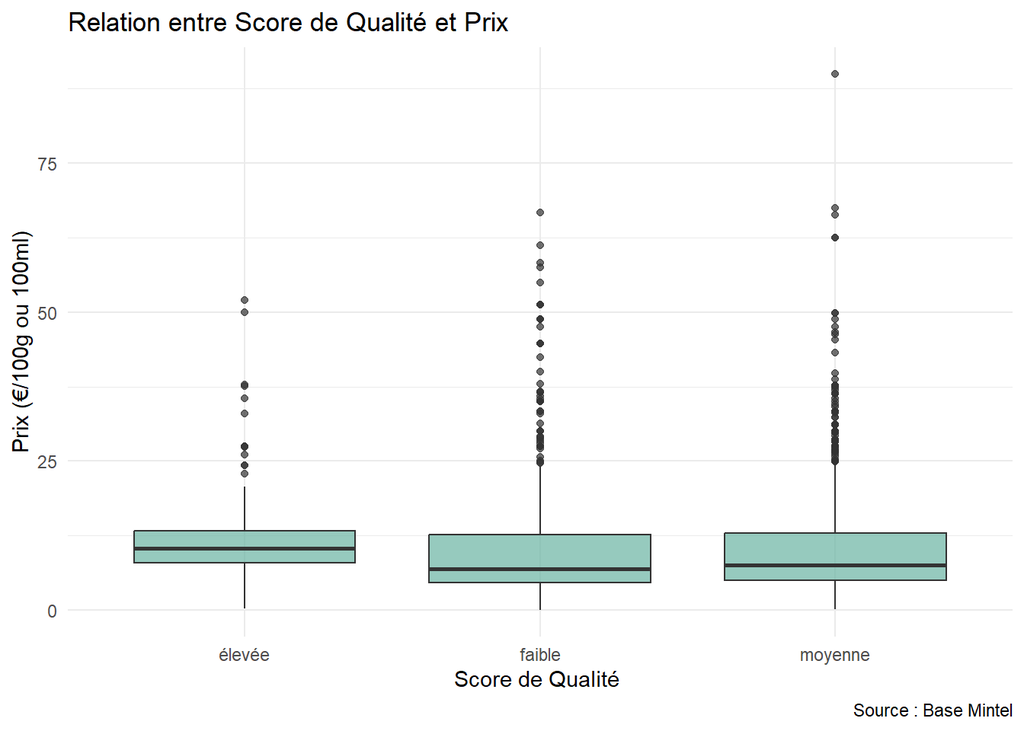

```r
ggplot(gnpd_french_market_tea, aes(x = factor(niveau_qualite), y = `Price per 100 g/ml in Euros`)) +
  geom_boxplot(fill = "#69b3a2", alpha = 0.7) +
  #geom_jitter(width = 0.2, alpha = 0.3, color = "grey30") +
  labs(
    title = "Relation entre Score de Qualité et Prix",
    x = "Score de Qualité ",
    y = "Prix (€/100g ou 100ml)",
    caption = "Source : Base Mintel"
  ) +
  theme_minimal()
```

```r
modele_score <- lm(`Price per 100 g/ml in Euros` ~ niveau_qualite, data = gnpd_french_market_tea)
summary(modele_score)
```

```
##
## Call:
## lm(formula = `Price per 100 g/ml in Euros` ~ niveau_qualite,
##     data = gnpd_french_market_tea)
##
## Residuals:
##     Min      1Q  Median      3Q     Max
## -11.877  -5.571  -3.031   2.089  79.429
##
## Coefficients:
##                       Estimate Std. Error t value Pr(>|t|)
## (Intercept)            12.1771     0.7613  15.995   <2e-16 ***
## niveau_qualitefaible   -1.7078     0.8633  -1.978   0.0481 *
## niveau_qualitemoyenne  -1.6066     0.8170  -1.966   0.0494 *
## ---
## Signif. codes:  0 '***' 0.001 '**' 0.01 '*' 0.05 '.' 0.1 ' ' 1
##
## Residual standard error: 9.509 on 1728 degrees of freedom
## Multiple R-squared:  0.002466,   Adjusted R-squared:  0.001311
## F-statistic: 2.136 on 2 and 1728 DF,  p-value: 0.1185
```